# **PRÁTICA ESTATÍSTICA II**

**ATIVIDADE AVALIATIVA 6: PROJETO I**  
Consumo de doces na pandemia de COVID-19

Luiza Braga Cândido (luizacandido@id.uff.br)

Universidade Federal Fluminense

20/10/2026

# INTRODUÇÃO

## Contexto

- A pandemia
- Doces
- A COVID-19 alterou a dinâmica da população: **isolamento social**, trabalho remoto e fechamento de comércios e serviços;
- Impactos emocionais: segundo a Fiocruz (2020), durante a pandemia, 52,6% dos adultos no Brasil relataram sentir-se frequentemente ansiosos ou nervosos.
- Alimentos ricos em açúcar costumam ser buscados como **conforto** em períodos de estresse, o chamado **comer emocional**;
- O levantamento do Grupo Pão de Açúcar (GPA), noticiado na Veja, documentou o aumento nas vendas de chocolates e guloseimas logo nos primeiros meses de confinamento em 2020.

## Problema e objetivos

- Problema de pesquisa
- Objetivos

**Quais fatores estão associados às mudanças no consumo de doces durante a pandemia de COVID-19?**

- Variável resposta: **`Doces`**, mudança no consumo de doces;
- Categorias: **Aumentou**, **Diminuiu**, **Não alterou** e **Não consumo**.

**Objetivo geral**

- Avaliar a associação entre a mudança no consumo de doces e as variáveis explicativas do banco de dados.

**Objetivos específicos**

- Investigar a relação com características **sociodemográficas e econômicas**;
- Avaliar fatores ligados à **pandemia e à saúde**;
- Avaliar a relação com a **saúde emocional**;
- Comparar **idade, peso, altura e IMC** entre as categorias de mudança.

# METODOLOGIA

## Os dados

- Origem
- Variável resposta
- Variáveis explicativas
- **Questionário online** aplicado em **2022**, durante a pandemia de COVID-19;
- Dados coletados por alunas da **pós-graduação em Nutrição da UFF**;
- **n = 2.155** adultos;
- Nenhum dado faltante nas variáveis analisadas.

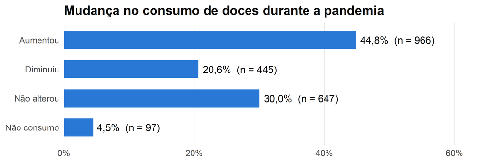

**Categóricas (15)**

- **Sociodemográficas:** gênero, raça/cor, região, escolaridade;
- **Socioeconômicas:** renda familiar, trabalho, dificuldade financeira;
- **Pandemia e saúde:** isolamento, COVID-19, nutricionista, fumo;
- **Saúde emocional:** ansiedade, depressão, insônia, enxaqueca.

**Quantitativas (4)**

- Idade (anos);
- Peso (kg);
- Altura (m);
- IMC (kg/m²).

## Tratamento dos dados

Categorias com **pouquíssimas observações** foram agrupadas ou excluídas, para garantir frequências esperadas adequadas no qui-quadrado:

| Variável | Ajuste | Excluídos |
| --- | --- | --- |
| Gênero | “Outro” (6) e “Prefiro não responder” (5) excluídos | 11 |
| Raça/cor | Amarela, Indígena e Outro agrupadas em **“Outras”** (39); “Prefiro não declarar” excluído | 28 |
| Escolaridade | Analfabeto, Fundamental e Médio agrupados em **“Até Ensino Médio”**; “Não desejo informar” excluído | 17 |

As exclusões valem apenas para o teste da própria variável. Nas demais análises, todos os 2.155 participantes foram mantidos.

## Métodos estatísticos

- Qui-quadrado
- V de Cramér
- Resíduos padronizados
- ANOVA de Welch
- Software
- Testa a **independência** entre a variável resposta e cada variável categórica;
- H₀: as variáveis são independentes; H₁: existe associação;
- **Suposições:** observações independentes e frequência esperada ≥ 5 em pelo menos 80% das caselas, sem nenhuma abaixo de 1;
- Se a suposição falhasse, seria usado o **teste exato de Fisher** (Monte Carlo). Após o tratamento dos dados, **todas as tabelas atenderam à suposição**.
- Mede a **intensidade** da associação, de 0 a 1;
- Necessário porque, com **n = 2.155**, até associações muito fracas ficam significativas;
- Referência usual de interpretação:

| V de Cramér | Até 0,10 | 0,10 a 0,30 | 0,30 a 0,50 | Acima de 0,50 |
| --- | --- | --- | --- | --- |
| Intensidade | Desprezível | Fraca | Moderada | Forte |

- O qui-quadrado diz **se** há associação; os resíduos mostram **onde** ela está;
- Resíduo padronizado ajustado com **|r| > 1,96** indica casela influente ao nível de 5%;
- Nas tabelas: **▲** mais casos que o esperado e **▼** menos casos que o esperado sob independência.
- Compara as **médias** de idade, peso, altura e IMC entre as 4 categorias da resposta;
- **Suposições:** independência e normalidade (com grupos grandes, garantida aproximadamente pelo TCL). **Não exige variâncias iguais**;
- Escolhida porque os grupos são **muito desbalanceados** (de 97 a 966 pessoas) e o **teste de Levene** indicou variâncias diferentes para idade e altura;
- Comparações múltiplas pelo teste de **Games-Howell**;
- **Kruskal-Wallis** usado como análise de sensibilidade.
- Nível de significância: **α = 5%**;
- Análises feitas no **R**, com os pacotes:
  - `readxl`: leitura da base;
  - `dplyr` e `tidyr`: manipulação dos dados;
  - `rstatix` e `car`: Games-Howell e teste de Levene;
  - `ggplot2`: gráficos.

# RESULTADOS

## Variáveis qualitativas

- Sociodemográficas
- Socioeconômicas
- Pandemia e saúde
- Saúde emocional

Tabela 1 - Mudança no consumo de doces segundo variáveis sociodemográficas.

| Variável | Aumentou N = 966 | Diminuiu N = 445 | Não alterou N = 647 | Não consumo N = 97 | Total | *p*-valor | V de Cramér |
| --- | --- | --- | --- | --- | --- | --- | --- |
| **Gênero** |  |  |  |  |  | **<0,001** | 0,173 |
| Feminino | 794 (49,6%) ▲ | 318 (19,9%) | 429 (26,8%) ▼ | 61 (3,8%) ▼ | 1.602 |  |  |
| Masculino | 166 (30,6%) ▼ | 124 (22,9%) | 217 (40,0%) ▲ | 35 (6,5%) ▲ | 542 |  |  |
| **Raça/cor** |  |  |  |  |  | 0,061 | 0,050 |
| Branca | 635 (47,2%) | 253 (18,8%) | 404 (30,0%) | 54 (4,0%) | 1.346 |  |  |
| Parda | 233 (40,5%) | 136 (23,6%) | 179 (31,1%) | 28 (4,9%) | 576 |  |  |
| Preta | 69 (41,6%) | 44 (26,5%) | 42 (25,3%) | 11 (6,6%) | 166 |  |  |
| Outras | 17 (43,6%) | 7 (17,9%) | 13 (33,3%) | 2 (5,1%) | 39 |  |  |
| **Região** |  |  |  |  |  | **0,002** | 0,070 |
| Norte | 112 (36,7%) ▼ | 72 (23,6%) | 100 (32,8%) | 21 (6,9%) ▲ | 305 |  |  |
| Nordeste | 125 (46,6%) | 57 (21,3%) | 76 (28,4%) | 10 (3,7%) | 268 |  |  |
| Centro-Oeste | 80 (36,9%) ▼ | 41 (18,9%) | 80 (36,9%) ▲ | 16 (7,4%) ▲ | 217 |  |  |
| Sudeste | 437 (48,2%) ▲ | 192 (21,2%) | 248 (27,3%) ▼ | 30 (3,3%) ▼ | 907 |  |  |
| Sul | 212 (46,3%) | 83 (18,1%) | 143 (31,2%) | 20 (4,4%) | 458 |  |  |
| **Escolaridade** |  |  |  |  |  | **<0,001** | 0,081 |
| Até Ensino Médio | 350 (46,8%) | 182 (24,3%) ▲ | 181 (24,2%) ▼ | 35 (4,7%) | 748 |  |  |
| Ensino Superior Completo | 190 (45,7%) | 88 (21,2%) | 123 (29,6%) | 15 (3,6%) | 416 |  |  |
| Pós-graduação | 416 (42,7%) | 172 (17,7%) ▼ | 340 (34,9%) ▲ | 46 (4,7%) | 974 |  |  |

Frequência absoluta e percentual por linha. *p*-valor do teste qui-quadrado de independência; em negrito quando *p* < 0,05. Nas variáveis com associação significativa, as caselas destacadas têm resíduo padronizado ajustado com |r| > 1,96: ▲ mais casos que o esperado sob independência; ▼ menos casos.

Tabela 2 - Mudança no consumo de doces segundo variáveis socioeconômicas.

| Variável | Aumentou N = 966 | Diminuiu N = 445 | Não alterou N = 647 | Não consumo N = 97 | Total | *p*-valor | V de Cramér |
| --- | --- | --- | --- | --- | --- | --- | --- |
| **Renda familiar** |  |  |  |  |  | **<0,001** | 0,074 |
| Até R$ 1.254 | 96 (39,2%) | 74 (30,2%) ▲ | 62 (25,3%) | 13 (5,3%) | 245 |  |  |
| R$ 1.255 a R$ 8.640 | 572 (46,5%) | 249 (20,2%) | 352 (28,6%) | 57 (4,6%) | 1.230 |  |  |
| Mais de R$ 8.640 | 298 (43,8%) | 122 (17,9%) ▼ | 233 (34,3%) ▲ | 27 (4,0%) | 680 |  |  |
| **Trabalha** |  |  |  |  |  | **<0,001** | 0,128 |
| Sim | 702 (44,3%) | 287 (18,1%) ▼ | 521 (32,9%) ▲ | 73 (4,6%) | 1.583 |  |  |
| Não | 264 (46,2%) | 158 (27,6%) ▲ | 126 (22,0%) ▼ | 24 (4,2%) | 572 |  |  |
| **Dificuldade financeira** |  |  |  |  |  | **<0,001** | 0,175 |
| Sim | 157 (39,8%) ▼ | 136 (34,5%) ▲ | 78 (19,8%) ▼ | 23 (5,8%) | 394 |  |  |
| Não | 809 (45,9%) ▲ | 309 (17,5%) ▼ | 569 (32,3%) ▲ | 74 (4,2%) | 1.761 |  |  |

Frequência absoluta e percentual por linha. *p*-valor do teste qui-quadrado de independência; em negrito quando *p* < 0,05. Nas variáveis com associação significativa, as caselas destacadas têm resíduo padronizado ajustado com |r| > 1,96: ▲ mais casos que o esperado sob independência; ▼ menos casos.

Tabela 3 - Mudança no consumo de doces segundo fatores da pandemia e saúde.

| Variável | Aumentou N = 966 | Diminuiu N = 445 | Não alterou N = 647 | Não consumo N = 97 | Total | *p*-valor | V de Cramér |
| --- | --- | --- | --- | --- | --- | --- | --- |
| **Isolamento social** |  |  |  |  |  | **0,031** | 0,064 |
| Sim | 566 (47,0%) ▲ | 250 (20,8%) | 331 (27,5%) ▼ | 56 (4,7%) | 1.203 |  |  |
| Não | 400 (42,0%) ▼ | 195 (20,5%) | 316 (33,2%) ▲ | 41 (4,3%) | 952 |  |  |
| **Teve COVID-19** |  |  |  |  |  | 0,300 | 0,041 |
| Sim | 279 (47,9%) | 110 (18,9%) | 166 (28,5%) | 28 (4,8%) | 583 |  |  |
| Não | 687 (43,7%) | 335 (21,3%) | 481 (30,6%) | 69 (4,4%) | 1.572 |  |  |
| **Consultou nutricionista** |  |  |  |  |  | **<0,001** | 0,087 |
| Sim | 192 (47,1%) | 96 (23,5%) | 93 (22,8%) ▼ | 27 (6,6%) ▲ | 408 |  |  |
| Não | 774 (44,3%) | 349 (20,0%) | 554 (31,7%) ▲ | 70 (4,0%) ▼ | 1.747 |  |  |
| **Fuma** |  |  |  |  |  | **0,027** | 0,065 |
| Sim | 42 (40,0%) | 27 (25,7%) | 26 (24,8%) | 10 (9,5%) ▲ | 105 |  |  |
| Não | 924 (45,1%) | 418 (20,4%) | 621 (30,3%) | 87 (4,2%) ▼ | 2.050 |  |  |

Frequência absoluta e percentual por linha. *p*-valor do teste qui-quadrado de independência; em negrito quando *p* < 0,05. Nas variáveis com associação significativa, as caselas destacadas têm resíduo padronizado ajustado com |r| > 1,96: ▲ mais casos que o esperado sob independência; ▼ menos casos.

Tabela 4 - Mudança no consumo de doces segundo saúde emocional.

| Variável | Aumentou N = 966 | Diminuiu N = 445 | Não alterou N = 647 | Não consumo N = 97 | Total | *p*-valor | V de Cramér |
| --- | --- | --- | --- | --- | --- | --- | --- |
| **Ansiedade** |  |  |  |  |  | **<0,001** | 0,164 |
| Sim | 552 (52,8%) ▲ | 202 (19,3%) | 248 (23,7%) ▼ | 44 (4,2%) | 1.046 |  |  |
| Não | 414 (37,3%) ▼ | 243 (21,9%) | 399 (36,0%) ▲ | 53 (4,8%) | 1.109 |  |  |
| **Depressão** |  |  |  |  |  | **<0,001** | 0,132 |
| Sim | 198 (56,7%) ▲ | 79 (22,6%) | 62 (17,8%) ▼ | 10 (2,9%) | 349 |  |  |
| Não | 768 (42,5%) ▼ | 366 (20,3%) | 585 (32,4%) ▲ | 87 (4,8%) | 1.806 |  |  |
| **Insônia** |  |  |  |  |  | **<0,001** | 0,097 |
| Sim | 151 (51,7%) ▲ | 70 (24,0%) | 55 (18,8%) ▼ | 16 (5,5%) | 292 |  |  |
| Não | 815 (43,7%) ▼ | 375 (20,1%) | 592 (31,8%) ▲ | 81 (4,3%) | 1.863 |  |  |
| **Enxaqueca** |  |  |  |  |  | **<0,001** | 0,099 |
| Sim | 172 (54,6%) ▲ | 67 (21,3%) | 70 (22,2%) ▼ | 6 (1,9%) ▼ | 315 |  |  |
| Não | 794 (43,2%) ▼ | 378 (20,5%) | 577 (31,4%) ▲ | 91 (4,9%) ▲ | 1.840 |  |  |

Frequência absoluta e percentual por linha. *p*-valor do teste qui-quadrado de independência; em negrito quando *p* < 0,05. Nas variáveis com associação significativa, as caselas destacadas têm resíduo padronizado ajustado com |r| > 1,96: ▲ mais casos que o esperado sob independência; ▼ menos casos.

## Intensidade das associações

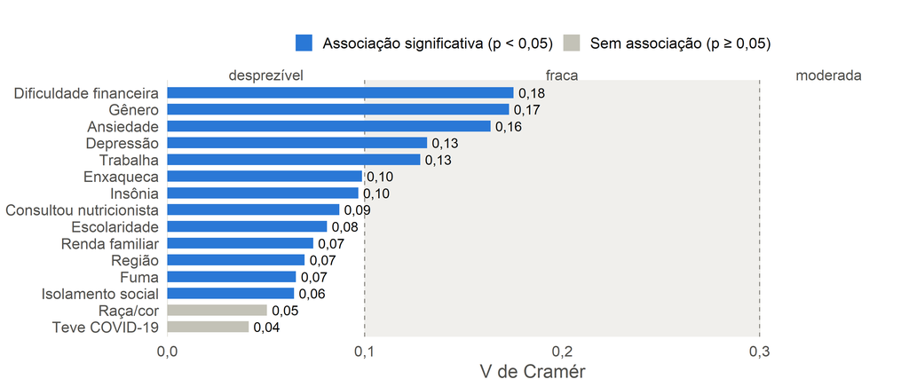

**Nenhuma associação chegou a ser moderada.** As mais “relevantes” (todas **fracas**), foram dificuldade financeira, gênero e ansiedade.

## Destaque: duas forças opostas

- Saúde emocional
- Fatores socioeconômicos
- Gênero

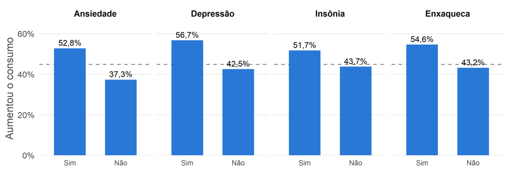

Linha tracejada: percentual geral que aumentou o consumo (44,8%). Quem relatou **ansiedade, depressão, insônia ou enxaqueca** aumentou mais o consumo de doces.

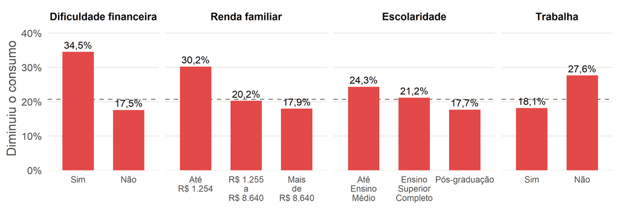

Linha tracejada: percentual geral que diminuiu o consumo (20,6%). Nos grupos **mais vulneráveis financeiramente**, a redução foi maior.

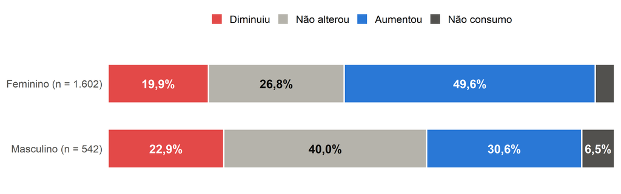

Entre as mulheres, **49,6% aumentaram** o consumo de doces, contra **30,6%** dos homens.

## Variáveis quantitativas

- Medidas resumo
- Comparações múltiplas

Tabela 5 - Variáveis quantitativas segundo a mudança no consumo de doces.

| Variável | Aumentou N = 966 | Diminuiu N = 445 | Não alterou N = 647 | Não consumo N = 97 | *p*-valor Welch | *p*-valor Levene | *p*-valor Kruskal-Wallis |
| --- | --- | --- | --- | --- | --- | --- | --- |
| **Idade (anos)** | 31,8 (10,7) 29,0 [23,0; 38,0] | 36,5 (14,2) 33,0 [24,0; 47,0] | 37,4 (12,5) 37,0 [26,0; 46,0] | 40,5 (15,0) 39,0 [26,0; 54,0] | **<0,001** | <0,001 | **<0,001** |
| **Peso (kg)** | 69,9 (16,0) 67,0 [58,0; 79,7] | 70,7 (16,5) 68,5 [59,0; 80,0] | 70,3 (15,7) 68,0 [58,0; 80,0] | 70,8 (15,5) 68,5 [60,0; 80,5] | 0,830 | 0,866 | 0,793 |
| **Altura (m)** | 1,65 (0,08) 1,64 [1,59; 1,70] | 1,66 (0,09) 1,65 [1,59; 1,71] | 1,67 (0,09) 1,65 [1,60; 1,72] | 1,67 (0,09) 1,66 [1,60; 1,73] | **<0,001** | 0,005 | **<0,001** |
| **IMC (kg/m²)** | 25,7 (5,2) 24,9 [21,9; 28,4] | 25,7 (5,3) 24,7 [22,1; 28,1] | 25,3 (4,8) 24,7 [21,6; 27,9] | 25,4 (4,8) 24,5 [22,1; 28,4] | 0,305 | 0,200 | 0,568 |

Média (desvio-padrão); abaixo, mediana [1º quartil; 3º quartil]. *p*-valor da ANOVA de Welch (teste principal), do teste de Levene para homogeneidade de variâncias e do teste de Kruskal-Wallis (análise de sensibilidade). Em negrito quando *p* < 0,05.

Tabela 6 - Pares com diferença significativa no teste de Games-Howell.

| Variável | Comparação | Diferença de médias | IC 95% | *p* ajustado |
| --- | --- | --- | --- | --- |
| **Idade (anos)** | Aumentou vs Diminuiu | -4,71 | [-6,66; -2,77] | **<0,001** |
| **Idade (anos)** | Aumentou vs Não alterou | -5,61 | [-7,15; -4,07] | **<0,001** |
| **Idade (anos)** | Aumentou vs Não consumo | -8,74 | [-12,82; -4,65] | **<0,001** |
| **Altura (m)** | Aumentou vs Não alterou | -0,018 | [-0,029; -0,007] | **<0,001** |

Diferença = média do primeiro grupo menos média do segundo. Apenas os pares com *p* ajustado < 0,05 são exibidos; os demais não diferiram. Peso (kg) e IMC (kg/m²) não apresentaram diferença na ANOVA de Welch.

## Interpretação dos resultados

- Emocionais
- Socioeconômicas
- Sociodemográficas
- Pandemia
- Quantitativas
- **Ansiedade** (V = 0,16): **52,8%** de quem relatou ansiedade aumentou o consumo de doces, contra **37,3%**;
- **Depressão** (V = 0,13): **56,7%** aumentaram, contra **42,5%**;
- **Insônia e enxaqueca** seguem o mesmo padrão, com associação mais fraca (V ≈ 0,10);
- **Dificuldade financeira** (V = 0,18): **34,5%** diminuíram o consumo, contra **17,5%** de quem não teve dificuldade;
- **Trabalho** (V = 0,13): quem não trabalhava diminuiu mais (**27,6%** contra **18,1%**);
- **Renda e escolaridade:** redução maior na renda até R$ 1.254 (**30,2%**) e até o Ensino Médio (**24,3%**), com associação desprezível (V < 0,10).
- **Gênero** (V = 0,17): **49,6%** das mulheres aumentaram o consumo, contra **30,6%** dos homens;
- **Região:** associação desprezível (V = 0,07). Sudeste aumentou mais; Norte e Centro-Oeste, menos;
- **Raça/cor:** **sem** associação (*p* = 0,061).
- **Isolamento social:** associação desprezível, com mais aumento entre os isolados (**47,0%** contra **42,0%**);
- **Consulta com nutricionista:** quem consultou mudou mais o hábito. Menos gente **manteve** o consumo (22,8% contra 31,7%);
- **Fumantes:** mais pessoas que **não consomem** doces (9,5% contra 4,2%);
- **Ter tido COVID-19:** **sem** associação.
- **Idade:** quem **aumentou** o consumo é **mais jovem** (média de 31,8 anos), de 4,7 a 8,7 anos a menos que os demais grupos;
- **Altura:** quem aumentou é um pouco mais baixo, mas isso é **efeito do gênero** (ver Discussão);
- **Peso e IMC:** **sem** diferença entre os grupos;
- Kruskal-Wallis confirmou as mesmas conclusões.

# CONCLUSÃO

## Principais achados

**Objetivo:** avaliar quais fatores se associam à mudança no consumo de doces durante a pandemia.

- Quase metade da amostra **aumentou** o consumo de doces (44,8%); 30,0% não alteraram e 20,6% diminuíram;
- **13 das 15** variáveis categóricas e **2 das 4** quantitativas apresentaram associação ao nível de 5%, mas **todas fracas**;
- Atuaram **duas forças opostas**: a **saúde emocional** puxou o consumo para cima e o **aperto financeiro** puxou para baixo;
- Quem mais aumentou: **mulheres**, **mais jovens** e quem relatou **ansiedade ou depressão**.

## Discussão

- Comer emocional
- Renda
- O caso da altura
- Significância × relevância
- A associação com ansiedade e depressão é coerente com o uso de doces como **conforto** em momentos de estresse;
- O efeito da ansiedade **se mantém dentro de cada gênero**: mulheres 56,4% contra 42,0%; homens 37,0% contra 26,9%;
- Ou seja, não é só porque mulheres relataram mais ansiedade (52,3% contra 36,9%).
- Com o orçamento apertado, doces são **fáceis de cortar**, por não serem essenciais;
- As duas forças podem agir **na mesma pessoa**: alguém ansioso e com dificuldade financeira;
- Uma análise **bivariada** não consegue separar esses efeitos.

Quem aumentou o consumo é mais baixo. Mas **dentro de cada gênero, a diferença some** (*p* = 0,17 nas mulheres e *p* = 0,90 nos homens).

- A altura só **parecia** associada porque as mulheres são mais baixas **e** aumentaram mais o consumo;
- É um exemplo concreto de **variável de confusão**.
- Com **n = 2.155**, até diferenças pequenas viram “significativas”;
- Todos os V de Cramér ficaram **abaixo de 0,20**: as associações existem, mas são **fracas**;
- O **V de Cramér** e os **resíduos** foram essenciais para separar o que é **relevante** do que é só estatisticamente detectável.

## Limitações

- **Estudo transversal:** mostra associação, mas **não causalidade**. Não dá para saber se a ansiedade levou ao consumo de doces ou se as duas coisas têm outra causa em comum;
- **Amostra por conveniência** (questionário online): tende a super-representar pessoas com **alta escolaridade** e acesso à internet (45% com pós-graduação);
- **Dados autorrelatados**, sujeitos a viés de memória;
- **Análises bivariadas**, sem controle de fatores de confusão, como mostrou o caso da altura. Uma regressão multinomial seria o próximo passo.

## Referências

1. MALTA, D. C. *et al.* A pandemia da COVID-19 e as mudanças no estilo de vida dos brasileiros adultos: um estudo transversal, 2020. **Epidemiologia e Serviços de Saúde**, v. 29, n. 4, e2020407, 2020.
2. BONIN, Robson. Pesquisa mostra como brasileiro se entregou aos doces na pandemia. Veja, Radar, 6 nov. 2020.
3. FUNDAÇÃO OSWALDO CRUZ (FIOCRUZ). ConVid Rede Pesquisa de Comportamentos: sentimentos, comportamentos e estilo de vida durante a pandemia de COVID-19. Rio de Janeiro: ICICT/Fiocruz, 2020.
4. AGRESTI, A. **Categorical data analysis**. 3. ed. Hoboken: Wiley, 2013.
5. COHEN, J. **Statistical power analysis for the behavioral sciences**. 2. ed. Hillsdale: Lawrence Erlbaum, 1988.
6. WELCH, B. L. On the comparison of several mean values: an alternative approach. **Biometrika**, v. 38, n. 3/4, p. 330-336, 1951.
7. GAMES, P. A.; HOWELL, J. F. Pairwise multiple comparison procedures with unequal *n*’s and/or variances: a Monte Carlo study. **Journal of Educational Statistics**, v. 1, n. 2, p. 113-125, 1976.
8. R CORE TEAM. **R: a language and environment for statistical computing**. Viena: R Foundation for Statistical Computing, 2025.